# Chapter 1. Your First Shiny App

Zhenhua Xu

*This is the study note following reading the book “Mastering Shiny” by Hadley Wickham.*

# 1 Introduction

In this chapter, we’ll create a simple Shiny app. We will see:

- The minimum bolierplate needed for a Shiny app.
- How to start and stop a Shiny app.
- Two key components of every Shiny app: **UI (defines how your app looks)** and **server function (defines how your app works).**
- The third important component of Shiny apps: **Reactive Expressions (fulfills the concept of Reactive Programming that Shiny uses).**

Firstly, install the Shiny package (version 1.5.0 or higher).  
Then, load Shiny in your current R session

```r
install.packages("shiny")
library(shiny)
```

```r
# You can check the package version you installed.
packageVersion("shiny")
```

# 2 Create app directory and file

The simplest way to crate a Shiny app is to create a new directory for your app, and put a single file called `app.R` in it. This file will be used to tell Shiny both how the app should look and behave.

**RStudio Tip:**  
Two convenient way to create a new Shiny app in RStudio:  
- **File -> New project -> New Directory -> Shniy Web Application.** This will create a new directory and an `app.R` file containing a basic app. - If you’ve already create the `app.R` file, you can quickly add the app boilerplate by typing `shinyapp` and pressing Shift+Tab.

```r
# Now in your app.R file, adding the following code:
library(shiny)

ui <- fluidPage(
    "Hello, world!"
)

server <- function(input, output, session) {

}

shinyApp(ui, server)
```

To run the app in RStudio, do one of the followings: - Click the **Run App** button in the `app.R` file toolbar. - Use keyboard shortcut: `Cmd/Ctrl + Shift + Enter`. - In the Console, call `shiny::runApp()`, with the path to the directory containing `app.R`.

You should see a window opens up in you web browser and printing `Hello, World!`.

This simple app reflects the two key components of a Shiny app:  
- `ui`, a variable referring to the codes in `fluidPage()`, is the UI of the app. - `server` a variable referring to the codes in `function()` is the server function.

In the R console, you should also see: Listening on http://127.0.0.1:3827. This URL is where your app can be found. 127.0.0.1 is a standard address meaning “this computer” and 3827 is a randomly assigned port number. So you can use this URL in a web browser to open another copy of the app.

To stop the app and return access to the console, use any one of these: - Click the stop sign icon on the R console toolbar. - Click on the console, then press `Esc` (or `Ctrl + C` if you are not using RStudio). - Close the Shiny app window in the web browser.

When more codes are added alongside the workflow of Shiny app development, it is not necessary to repeat the stop - start cycles everytime. You can either click the **Reload app** button in the toolbox or use `Cmd/Ctrl + Shift + Enter` shortcut to refresh the app.

# 3 Adding UI controls

Now, we start making a very simple app that shows all the built-in data frames included in the `datasets` package of R.  
First, we add other elements to the app UI.

```r
library(shiny)
ui <- fluidPage(
    selectInput("dataset", label = "Dataset", choices = ls("package:datasets")),
    verbatimTextOutput("summary"),
    tableOutput("table")
)

server <- function(input, output, session) {
}

shinyApp(ui, server)
```

**Code Explanation**: - `fluidPage()` is a **layout function** that sets up the basic visual structure of the page. - `selectInput()` is an **input control** that lets the user interact with the app by providing a value. In this case, it is a select box with the label `Dataset` and lets you choose one of the built-in datasets list that come with R. - `verbatimTextOutput()` and `tableOutput()` are **output controls** that tell Shiny **where** to put rendered output. `verbatimTextOutput()` displays code and `tableOutput()` displays tables.

Keep in minde that although layout functions, inputs, and outputs have different uses, they are fundamentally the same under the covers, which is hey’re all just fancy ways to generate HTML.

You should see the output like this:

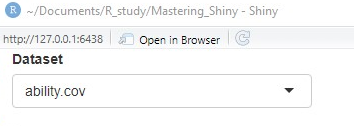

*Figure 1-1*

So far, we don’t see the outputs yet, because we haven’t told Shiny how the input and outputs are related.

# 4 Adding behaviour

Now we will tell Shiny how to fill in the `summary` and `table` outputs in the sample app by providing the “recipes” for those outputs.Change the `server` function with the following:

```r
server <- function(input, output, session) {
  output$summary <- renderPrint({
    dataset <- get(input$dataset, "package:datasets")
    summary(dataset)
})
  output$table <- renderTable({
    dataset <- get(input$dataset, "package:datasets")
    dataset
})
}
```

Code explanation: `output$ID` is a code format indicates that you are providing the recipe for the Shiny output with that `ID`. For example, `output$summary` and `output$table` means providing the recipe for the Shiny output with the ID `summary` and `table`, which corresponds to the names in `verbatimTextOutput("summary")` and `tableOutput("table")` in `fluidPage()`, respectively.

`render{Type}` function is designed **to produce a particular type of output (e.g. text, tables, and plots)**, and is often **paired with a `{type}Output` function**. For example, `renderPrint()` is paired with `verbatimTextOutput()` to display a fixed-width **(verbatim)** text; `renderTable()` is paired with `tableOutput()` to **show the input data in a table**.

You should see the output like this:

[figure not shown]

*Figure 1-2*

Play with different options, you should notice that the summary and table update whenever you change the input dataset.This dependency is created implicitly because we’ve referred to `input$dataset` within the output functions. `input$dataset` is populated with the current value of the UI component with id `dataset`, and causes the outputs to automatically update whenever that value changes.

*This is the essence of reactivity: outputs automatically react (recalculate) when their inputs change.*

# 5 Reducing duplication with reactive expressions

We should notice that in this simple example, we have code duplication: `dataset <- get(input$dataset, "package:datasets")`

In traditional R scripting, we use two techniques to deal with duplicated code: either we **capture the value using a variable**, or **capture the computation with a function**. Unfortunately **neither of these approaches work here**, reasons will be explaied in the next section. So we need a new mechanism: **reactive expressions**.

You create a reactive expression by: - wrapping a block of code in `reactive({...})`. - assigning it to a variable. - use a reactive expression by calling it like a function.

while it looks like you’re calling a function, a reactive expression has an important difference:

- It only runs the first time it is called.
- It caches its result until it needs to be updated.

That means, it only do the computation when it is needed. This fulfills the objectives of:

- Get called automatically when its dependent variable changes.
- Won’t do any computation when there is no update.

Now we update the `server()` function using reactive expressions to only retrieve the dataset once, not twice:

```r
server <- function(input, output, session) {
  # Create a reactive expression
  dataset <- reactive({
    get(input$dataset, "package:datasets")
  })

  output$summary <- renderPrint({
    # Use a reactive expression by calling it like a function
    summary(dataset())
  })
  output$table <- renderTable({
    dataset() # Same here, calling the reactive expression.
  })
}
```

# 6 Why do we need reactive programming?

Reactive programming is a style of programming that focuses on values that change over time, and calculations and actions that depend on those values.This is quite different from most R code, which typically deals with fairly static data.

For Shiny apps to be maximally useful, we need reactive expressions and outputs to update **if and only if** their inputs change. *We want outputs to stay in sync with inputs, while ensuring that we never do more work than necessary*.

## 6.1 Why can’t you use variables?

Variables in R represent values and they can change over time, but they’re not designed to help you when they change.

Take this simple example of converting a temperature from Celsius to Fahrenheit:

```r
temp_c <- 10
temp_f <- (temp_c * 9 / 5) + 32
temp_f
```

```
#> [1] 50
```

When we change `temp_c`, it doesn’t affect `temp_f`; unless we do the computation again:

```r
temp_c <- 30
temp_f
```

```
#> [1] 50
```

```r
temp_f <- (temp_c * 9 / 5) + 32
temp_f
```

[output not shown]

So, Variables can change over time, but they never change automatically.

## 6.2 How about functions?

Try to solve this problem with a function:

```r
temp_c <- 10
temp_f <- function() {
message("Converting")
(temp_c * 9 / 5) + 32
}
temp_f()
```

[output not shown]

This solves the first problem that reactivity is trying to solve: whenever you access `temp_f()` you get the latest computation:

```r
temp_c <- -3
temp_f()
```

```
#> Converting
#> [1] 26.6
```

It doesn’t, however, minimise computation. Every time you call `temp_f()` it recomputes, even if `temp_c` hasn’t changed. And **needlessly repeating is unnecessary: if the inputs haven’t changed, why do we need to recompute the output?**

## 6.3 Reactive programming

Reactive programming elegantly solves both problems by combining features of the solutions above.

In Shiny, we create a reactive value with `reactiveVal()`. A reactive value has special syntax for getting its value (calling it like a zero-argument function) and setting its value (set its value by calling it like a one-argument function).

```r
temp_c <- reactiveVal(10) # create
temp_c() # get
```

```
#> [1] 10
```

```r
temp_c(20) # set
temp_c() # get
```

```
#> [1] 20
```

Now we can create a reactive expression that depends on this value:

```r
temp_f <- reactive({
  message("Converting")
  (temp_c() * 9 / 5) + 32
})
temp_f()
```

```
#> Converting
#> [1] 68
```

A reactive expression automatically tracks all of its dependencies. So that later, if `temp_c` changes, `temp_f` will automatically update:

```r
temp_c(-3)
temp_c(-10)
temp_f()
```

```
#> Converting
#> [1] 14
```

But if `temp_c()` hasn’t changed, then `temp_f()` doesn’t need to recompute , and can just be retrieved from the cache:

```r
temp_f()
```

```
#> [1] 14
```

A reactive expression has two important properties:

- It’s lazy: it doesn’t do any work until it’s called.
- It’s cached: it doesn’t do any work the second and subsequent times it’s called because it caches the previous result.

More details will be learned in a later chapter.

# 7 Exercises

**1. Create an app that greets the user by name. You don’t know all the functions you need to do this yet, so I’ve included some lines of code below. Think about which lines you’ll use and then copy and paste them into the right place in a Shiny app.**

```r
tableOutput("mortgage")
output$greeting <- renderText({
  paste0("Hello ", input$name)
})
numericInput("age", "How old are you?", value = NA)
textInput("name", "What's your name?")
textOutput("greeting")
output$histogram <- renderPlot({
  hist(rnorm(1000))
}, res = 96)
```

**Solution:**

```r
library(shiny)

ui <- fluidPage(
  textInput("name", "What's your name?"),
  textOutput("greeting")
)

server <- function(input, output, session) {
  output$greeting <- renderText({
  paste0("Hello ", input$name)
  })
}

shinyApp(ui, server)
```

**2. Suppose your friend wants to design an app that allows the user to set a number (x) between 1 and 50, and displays the result of multiplying this number by 5. This is their first attempt:**

```r
library(shiny)

ui <- fluidPage(
  sliderInput("x", label = "If x is", min = 1, max =
50, value = 30),
  "then x times 5 is",
  textOutput("product")
)

server <- function(input, output, session) {
  output$product <- renderText({
    x * 5
  })
}
shinyApp(ui, server)
```

But unfortunately it has an error:

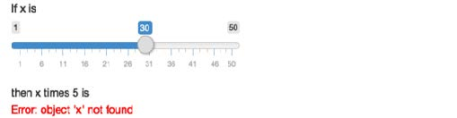

Can you help them find and correct the error?

**Solution:**  
On the server side, element `x` doesn’t exist. `x` only exists within `input`.

```r
library(shiny)

ui <- fluidPage(
  sliderInput("x", label = "If x is", min = 1, max = 50, value = 30),
  "then x times 5 is",
  textOutput("product")
)

server <- function(input, output, session) {
  output$product <- renderText({
    input$x * 5
  })
}
shinyApp(ui, server)
```

**3. Extend the app from the previous exercise to allow the user to set the value of the multiplier, `y`, so that the app yields the value of `x * y`. The final result should look like this:**

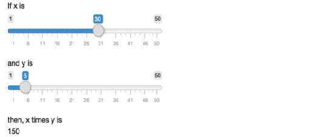

**Solution:**

```r
library(shiny)

ui <- fluidPage(
  sliderInput("x", label = "If x is", min = 1, max = 50, value = 30),
  sliderInput("y", label = "and y is", min = 1, max = 50, value = 5),
  "then x times y is",
  textOutput("product")
)

server <- function(input, output, session) {
  output$product <- renderText({
    input$x * input$y
  })
}
shinyApp(ui, server)
```

**4. Take the following app which adds some additional functionality to the last app described in the last exercise. What’s new? How could you reduce the amount of duplicated code in the app by using a reactive expression?**

```r
library(shiny)

ui <- fluidPage(
  sliderInput("x", "If x is", min = 1, max = 50, value = 30),
  sliderInput("y", "and y is", min = 1, max = 50, value = 5),
  "then, (x * y) is", textOutput("product"),
  "and, (x * y) + 5 is", textOutput("product_plus5"),
  "and (x * y) + 10 is", textOutput("product_plus10")
)

server <- function(input, output, session) {
  output$product <- renderText({
    product <- input$x * input$y
    product
  })
  output$product_plus5 <- renderText({
    product <- input$x * input$y
    product + 5
  })
  output$product_plus10 <- renderText({
    product <- input$x * input$y
    product + 10
  })
}

shinyApp(ui, server)
```

**Solution:**  
This app add functionality to calculate `x*y+5` and `x*y+10`.  
To use reactive expression:

```r
library(shiny)

ui <- fluidPage(
  sliderInput("x", "If x is", min = 1, max = 50, value = 30),
  sliderInput("y", "and y is", min = 1, max = 50, value = 5),
  "then, (x * y) is", textOutput("product"),
  "and, (x * y) + 5 is", textOutput("product_plus5"),
  "and (x * y) + 10 is", textOutput("product_plus10")
)

server <- function(input, output, session) {
  product <- reactive(input$x * input$y)

  output$product <- renderText({
    product()
  })
  output$product_plus5 <- renderText({
    product() + 5
  })
  output$product_plus10 <- renderText({
    product() + 10
  })
}

shinyApp(ui, server)
```

**5. The following app is very similar to one you’ve seen earlier in the chapter: you select a dataset from a package (this time we’re using the ggplot2 package) and the app prints out a summary and plot of the data. It also follows good practice and makes use of reactive expressions to avoid redundancy of code. However there are three bugs in the code provided below. Can you find and fix them?**

```r
library(shiny)
library(ggplot2)

datasets <- c("economics", "faithfuld", "seals")
ui <- fluidPage(
  selectInput("dataset", "Dataset", choices = datasets),
  verbatimTextOutput("summary"),
  tableOutput("plot")
)

server <- function(input, output, session) {
  dataset <- reactive({
    get(input$dataset, "package:ggplot2")
  })
  output$summmry <- renderPrint({
    summary(dataset())
  })
  output$plot <- renderPlot({
    plot(dataset)
  }, res = 96)
}

shinyApp(ui, server)
```

**Solution:**

- Bug 1: `plotOutput` should be used for plots.
- Bug 2: `output$summmry` is a typo, should be `output$summary`
- Bug 3: `plot(dataset)`, it should be `plot(dataset())`

```r
library(shiny)
library(ggplot2)

datasets <- c("economics", "faithfuld", "seals")
ui <- fluidPage(
  selectInput("dataset", "Dataset", choices = datasets),
  verbatimTextOutput("summary"),
  plotOutput("plot")
)

server <- function(input, output, session) {
  dataset <- reactive({
    get(input$dataset, "package:ggplot2")
  })
  output$summary <- renderPrint({
    summary(dataset())
  })
  output$plot <- renderPlot({
    plot(dataset())}, res = 96
  )
}

shinyApp(ui, server)
```